# Assignment #1 - Linear Regression

Name : **Siddhi Degaonkar**

# Introduction

**Purpose and Objective**: Assignment # 1 is implemented in order to describe and visualize the data and build linear model. Successfully implement Linear Regression to predict the target variable.

**Scope of Assignment** Assignment # 1 consist of introduction to Linear models, Implementation of Linear Regression on Diamond Dataset.

1. Introduce data and data source
2. Read and analyze the raw data from csv file.
3. Data preprocessing activities like: checking and filling up missing values, reducing noisy data, removing inconsistent data.
4. Data Visualization: Data Visualization is used to represent the data in graphical or pictorial manner. It makes the data more interpretable.
5. Extracting observations from visualized data.
6. Build Linear model.
7. Implement LS and LMS.
8. Train and use model using Least Square.
9. Train and use the model using Least Mean Square.
10. Analysis / comparison of algorithms.

**Conclusion** is derived and **references** are presented.

# Data Description

**Source**

- This dataset is obtained from Kaggle.

```python
import pandas as pd
import numpy as np
import seaborn as sns
from mpl_toolkits.mplot3d import Axes3D
import matplotlib.pyplot as plt
%matplotlib inline
df = pd.read_csv('diamonds.csv')
df.head(10)
```

|  | Unnamed: 0 | carat | cut | color | clarity | depth | table | price | x | y | z |
| --- | --- | --- | --- | --- | --- | --- | --- | --- | --- | --- | --- |
| 0 | 1 | 0.23 | Ideal | E | SI2 | 61.5 | 55.0 | 326 | 3.95 | 3.98 | 2.43 |
| 1 | 2 | 0.21 | Premium | E | SI1 | 59.8 | 61.0 | 326 | 3.89 | 3.84 | 2.31 |
| 2 | 3 | 0.23 | Good | E | VS1 | 56.9 | 65.0 | 327 | 4.05 | 4.07 | 2.31 |
| 3 | 4 | 0.29 | Premium | I | VS2 | 62.4 | 58.0 | 334 | 4.20 | 4.23 | 2.63 |
| 4 | 5 | 0.31 | Good | J | SI2 | 63.3 | 58.0 | 335 | 4.34 | 4.35 | 2.75 |
| 5 | 6 | 0.24 | Very Good | J | VVS2 | 62.8 | 57.0 | 336 | 3.94 | 3.96 | 2.48 |
| 6 | 7 | 0.24 | Very Good | I | VVS1 | 62.3 | 57.0 | 336 | 3.95 | 3.98 | 2.47 |
| 7 | 8 | 0.26 | Very Good | H | SI1 | 61.9 | 55.0 | 337 | 4.07 | 4.11 | 2.53 |
| 8 | 9 | 0.22 | Fair | E | VS2 | 65.1 | 61.0 | 337 | 3.87 | 3.78 | 2.49 |
| 9 | 10 | 0.23 | Very Good | H | VS1 | 59.4 | 61.0 | 338 | 4.00 | 4.05 | 2.39 |

```python
print(df.shape)
```

```
(53940, 11)
```

```python
print("MATCH dataset consists of total {rows} rows.".format(rows = len(df)))
```

```
MATCH dataset consists of total 53940 rows.
```

```python
df.info()
```

```
<class 'pandas.core.frame.DataFrame'>
RangeIndex: 53940 entries, 0 to 53939
Data columns (total 11 columns):
Unnamed: 0    53940 non-null int64
carat         53940 non-null float64
cut           53940 non-null object
color         53940 non-null object
clarity       53940 non-null object
depth         53940 non-null float64
table         53940 non-null float64
price         53940 non-null int64
x             53940 non-null float64
y             53940 non-null float64
z             53940 non-null float64
dtypes: float64(6), int64(2), object(3)
memory usage: 4.5+ MB
```

**DATA PREPROCESSING**

```python
#Calculate percentage of missing values for each column
missing_values = df.isnull().mean()
missing_values.sum()
```

```
0.0
```

- Dataset has **NO** missing values.
- Dropping the Unnamed column

```python
df = pd.read_csv('diamonds.csv', index_col=0)
df
```

|  | carat | cut | color | clarity | depth | table | price | x | y | z |
| --- | --- | --- | --- | --- | --- | --- | --- | --- | --- | --- |
| 1 | 0.23 | Ideal | E | SI2 | 61.5 | 55.0 | 326 | 3.95 | 3.98 | 2.43 |
| 2 | 0.21 | Premium | E | SI1 | 59.8 | 61.0 | 326 | 3.89 | 3.84 | 2.31 |
| 3 | 0.23 | Good | E | VS1 | 56.9 | 65.0 | 327 | 4.05 | 4.07 | 2.31 |
| 4 | 0.29 | Premium | I | VS2 | 62.4 | 58.0 | 334 | 4.20 | 4.23 | 2.63 |
| 5 | 0.31 | Good | J | SI2 | 63.3 | 58.0 | 335 | 4.34 | 4.35 | 2.75 |
| 6 | 0.24 | Very Good | J | VVS2 | 62.8 | 57.0 | 336 | 3.94 | 3.96 | 2.48 |
| 7 | 0.24 | Very Good | I | VVS1 | 62.3 | 57.0 | 336 | 3.95 | 3.98 | 2.47 |
| 8 | 0.26 | Very Good | H | SI1 | 61.9 | 55.0 | 337 | 4.07 | 4.11 | 2.53 |
| 9 | 0.22 | Fair | E | VS2 | 65.1 | 61.0 | 337 | 3.87 | 3.78 | 2.49 |
| 10 | 0.23 | Very Good | H | VS1 | 59.4 | 61.0 | 338 | 4.00 | 4.05 | 2.39 |
| 11 | 0.30 | Good | J | SI1 | 64.0 | 55.0 | 339 | 4.25 | 4.28 | 2.73 |
| 12 | 0.23 | Ideal | J | VS1 | 62.8 | 56.0 | 340 | 3.93 | 3.90 | 2.46 |
| 13 | 0.22 | Premium | F | SI1 | 60.4 | 61.0 | 342 | 3.88 | 3.84 | 2.33 |
| 14 | 0.31 | Ideal | J | SI2 | 62.2 | 54.0 | 344 | 4.35 | 4.37 | 2.71 |
| 15 | 0.20 | Premium | E | SI2 | 60.2 | 62.0 | 345 | 3.79 | 3.75 | 2.27 |
| 16 | 0.32 | Premium | E | I1 | 60.9 | 58.0 | 345 | 4.38 | 4.42 | 2.68 |
| 17 | 0.30 | Ideal | I | SI2 | 62.0 | 54.0 | 348 | 4.31 | 4.34 | 2.68 |
| 18 | 0.30 | Good | J | SI1 | 63.4 | 54.0 | 351 | 4.23 | 4.29 | 2.70 |
| 19 | 0.30 | Good | J | SI1 | 63.8 | 56.0 | 351 | 4.23 | 4.26 | 2.71 |
| 20 | 0.30 | Very Good | J | SI1 | 62.7 | 59.0 | 351 | 4.21 | 4.27 | 2.66 |
| 21 | 0.30 | Good | I | SI2 | 63.3 | 56.0 | 351 | 4.26 | 4.30 | 2.71 |
| 22 | 0.23 | Very Good | E | VS2 | 63.8 | 55.0 | 352 | 3.85 | 3.92 | 2.48 |
| 23 | 0.23 | Very Good | H | VS1 | 61.0 | 57.0 | 353 | 3.94 | 3.96 | 2.41 |
| 24 | 0.31 | Very Good | J | SI1 | 59.4 | 62.0 | 353 | 4.39 | 4.43 | 2.62 |
| 25 | 0.31 | Very Good | J | SI1 | 58.1 | 62.0 | 353 | 4.44 | 4.47 | 2.59 |
| 26 | 0.23 | Very Good | G | VVS2 | 60.4 | 58.0 | 354 | 3.97 | 4.01 | 2.41 |
| 27 | 0.24 | Premium | I | VS1 | 62.5 | 57.0 | 355 | 3.97 | 3.94 | 2.47 |
| 28 | 0.30 | Very Good | J | VS2 | 62.2 | 57.0 | 357 | 4.28 | 4.30 | 2.67 |
| 29 | 0.23 | Very Good | D | VS2 | 60.5 | 61.0 | 357 | 3.96 | 3.97 | 2.40 |
| 30 | 0.23 | Very Good | F | VS1 | 60.9 | 57.0 | 357 | 3.96 | 3.99 | 2.42 |
| ... | ... | ... | ... | ... | ... | ... | ... | ... | ... | ... |
| 53911 | 0.70 | Premium | E | SI1 | 60.5 | 58.0 | 2753 | 5.74 | 5.77 | 3.48 |
| 53912 | 0.57 | Premium | E | IF | 59.8 | 60.0 | 2753 | 5.43 | 5.38 | 3.23 |
| 53913 | 0.61 | Premium | F | VVS1 | 61.8 | 59.0 | 2753 | 5.48 | 5.40 | 3.36 |
| 53914 | 0.80 | Good | G | VS2 | 64.2 | 58.0 | 2753 | 5.84 | 5.81 | 3.74 |
| 53915 | 0.84 | Good | I | VS1 | 63.7 | 59.0 | 2753 | 5.94 | 5.90 | 3.77 |
| 53916 | 0.77 | Ideal | E | SI2 | 62.1 | 56.0 | 2753 | 5.84 | 5.86 | 3.63 |
| 53917 | 0.74 | Good | D | SI1 | 63.1 | 59.0 | 2753 | 5.71 | 5.74 | 3.61 |
| 53918 | 0.90 | Very Good | J | SI1 | 63.2 | 60.0 | 2753 | 6.12 | 6.09 | 3.86 |
| 53919 | 0.76 | Premium | I | VS1 | 59.3 | 62.0 | 2753 | 5.93 | 5.85 | 3.49 |
| 53920 | 0.76 | Ideal | I | VVS1 | 62.2 | 55.0 | 2753 | 5.89 | 5.87 | 3.66 |
| 53921 | 0.70 | Very Good | E | VS2 | 62.4 | 60.0 | 2755 | 5.57 | 5.61 | 3.49 |
| 53922 | 0.70 | Very Good | E | VS2 | 62.8 | 60.0 | 2755 | 5.59 | 5.65 | 3.53 |
| 53923 | 0.70 | Very Good | D | VS1 | 63.1 | 59.0 | 2755 | 5.67 | 5.58 | 3.55 |
| 53924 | 0.73 | Ideal | I | VS2 | 61.3 | 56.0 | 2756 | 5.80 | 5.84 | 3.57 |
| 53925 | 0.73 | Ideal | I | VS2 | 61.6 | 55.0 | 2756 | 5.82 | 5.84 | 3.59 |
| 53926 | 0.79 | Ideal | I | SI1 | 61.6 | 56.0 | 2756 | 5.95 | 5.97 | 3.67 |
| 53927 | 0.71 | Ideal | E | SI1 | 61.9 | 56.0 | 2756 | 5.71 | 5.73 | 3.54 |
| 53928 | 0.79 | Good | F | SI1 | 58.1 | 59.0 | 2756 | 6.06 | 6.13 | 3.54 |
| 53929 | 0.79 | Premium | E | SI2 | 61.4 | 58.0 | 2756 | 6.03 | 5.96 | 3.68 |
| 53930 | 0.71 | Ideal | G | VS1 | 61.4 | 56.0 | 2756 | 5.76 | 5.73 | 3.53 |
| 53931 | 0.71 | Premium | E | SI1 | 60.5 | 55.0 | 2756 | 5.79 | 5.74 | 3.49 |
| 53932 | 0.71 | Premium | F | SI1 | 59.8 | 62.0 | 2756 | 5.74 | 5.73 | 3.43 |
| 53933 | 0.70 | Very Good | E | VS2 | 60.5 | 59.0 | 2757 | 5.71 | 5.76 | 3.47 |
| 53934 | 0.70 | Very Good | E | VS2 | 61.2 | 59.0 | 2757 | 5.69 | 5.72 | 3.49 |
| 53935 | 0.72 | Premium | D | SI1 | 62.7 | 59.0 | 2757 | 5.69 | 5.73 | 3.58 |
| 53936 | 0.72 | Ideal | D | SI1 | 60.8 | 57.0 | 2757 | 5.75 | 5.76 | 3.50 |
| 53937 | 0.72 | Good | D | SI1 | 63.1 | 55.0 | 2757 | 5.69 | 5.75 | 3.61 |
| 53938 | 0.70 | Very Good | D | SI1 | 62.8 | 60.0 | 2757 | 5.66 | 5.68 | 3.56 |
| 53939 | 0.86 | Premium | H | SI2 | 61.0 | 58.0 | 2757 | 6.15 | 6.12 | 3.74 |
| 53940 | 0.75 | Ideal | D | SI2 | 62.2 | 55.0 | 2757 | 5.83 | 5.87 | 3.64 |

53940 rows × 10 columns

**DATA VISUALIZATION AND PREPROCESSING FOR DIAMOND DATASET**

```python
df.describe()
```

|  | carat | depth | table | price | x | y | z |
| --- | --- | --- | --- | --- | --- | --- | --- |
| count | 53940.000000 | 53940.000000 | 53940.000000 | 53940.000000 | 53940.000000 | 53940.000000 | 53940.000000 |
| mean | 0.797940 | 61.749405 | 57.457184 | 3932.799722 | 5.731157 | 5.734526 | 3.538734 |
| std | 0.474011 | 1.432621 | 2.234491 | 3989.439738 | 1.121761 | 1.142135 | 0.705699 |
| min | 0.200000 | 43.000000 | 43.000000 | 326.000000 | 0.000000 | 0.000000 | 0.000000 |
| 25% | 0.400000 | 61.000000 | 56.000000 | 950.000000 | 4.710000 | 4.720000 | 2.910000 |
| 50% | 0.700000 | 61.800000 | 57.000000 | 2401.000000 | 5.700000 | 5.710000 | 3.530000 |
| 75% | 1.040000 | 62.500000 | 59.000000 | 5324.250000 | 6.540000 | 6.540000 | 4.040000 |
| max | 5.010000 | 79.000000 | 95.000000 | 18823.000000 | 10.740000 | 58.900000 | 31.800000 |

- The minimum values for x,y and z shown are 0 but it is not possible because the length, width and depth cannot be zero.

```python
print("No. of rows with x == 0: {} ".format((df.x==0).sum()))
print("No. of rows with y == 0: {} ".format((df.y==0).sum()))
print("No. of rows with z == 0: {} ".format((df.z==0).sum()))
```

```
No. of rows with x == 0: 8
No. of rows with y == 0: 7
No. of rows with z == 0: 20
```

```python
df.dropna(inplace=True)
df.shape
```

```
(53940, 10)
```

```python
df.isnull().sum()
```

```
carat      0
cut        0
color      0
clarity    0
depth      0
table      0
price      0
x          0
y          0
z          0
dtype: int64
```

```python
volume = df['x']*df['y']*df['z']
df = df.assign(volume = df['x']*df['y']*df['z'])
df.head()
```

|  | carat | cut | color | clarity | depth | table | price | x | y | z | volume |
| --- | --- | --- | --- | --- | --- | --- | --- | --- | --- | --- | --- |
| 1 | 0.23 | Ideal | E | SI2 | 61.5 | 55.0 | 326 | 3.95 | 3.98 | 2.43 | 38.202030 |
| 2 | 0.21 | Premium | E | SI1 | 59.8 | 61.0 | 326 | 3.89 | 3.84 | 2.31 | 34.505856 |
| 3 | 0.23 | Good | E | VS1 | 56.9 | 65.0 | 327 | 4.05 | 4.07 | 2.31 | 38.076885 |
| 4 | 0.29 | Premium | I | VS2 | 62.4 | 58.0 | 334 | 4.20 | 4.23 | 2.63 | 46.724580 |
| 5 | 0.31 | Good | J | SI2 | 63.3 | 58.0 | 335 | 4.34 | 4.35 | 2.75 | 51.917250 |

```python
df.nunique()
```

```
carat        273
cut            5
color          7
clarity        8
depth        184
table        127
price      11602
x            554
y            552
z            375
volume     28465
dtype: int64
```

**DATA PLOTS FOR UNDERSTANDING**

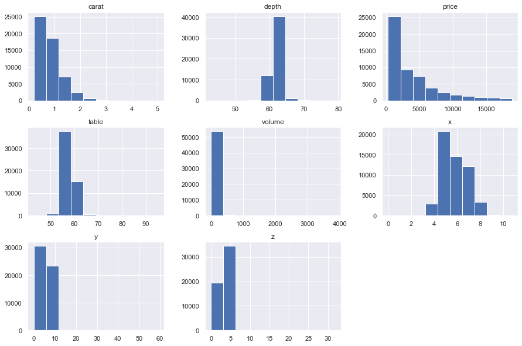

```python
h = df.hist(figsize=(15,10))
```

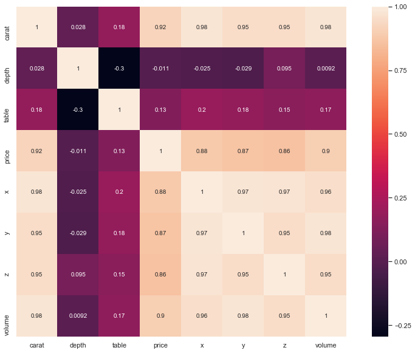

```python
plt.figure(figsize=(15, 10))
corr_map = df.corr()
sns.heatmap(data=corr_map, square=True , annot=True, cbar=True)
```

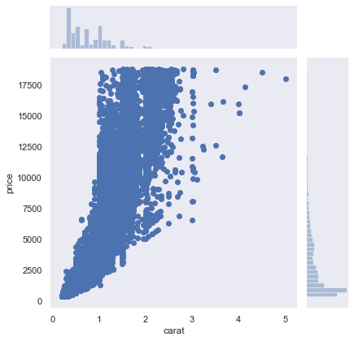

```python
sns.set(style="dark", color_codes= False)
g = sns.jointplot(y="price", x="carat", data=df)
```

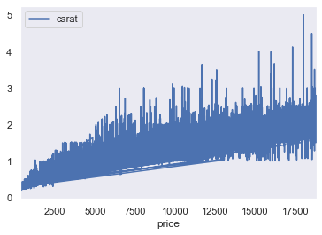

```python
df.plot(x='price', y='carat')
```

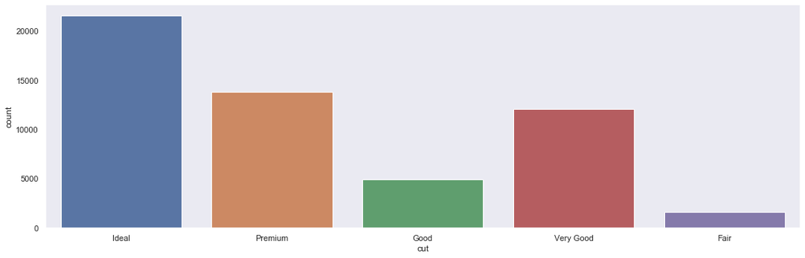

```python
p = sns.factorplot(x='cut', data=df , kind='count',aspect=3 )
```

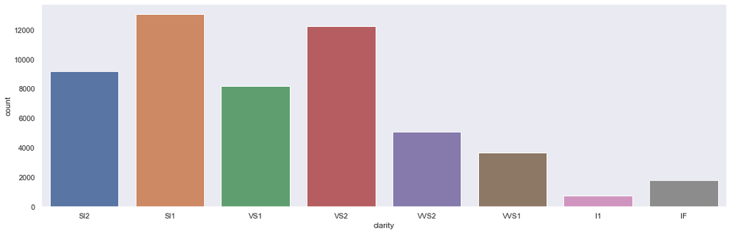

```python
p = sns.factorplot(x='clarity', data=df , kind='count',aspect=3)
```

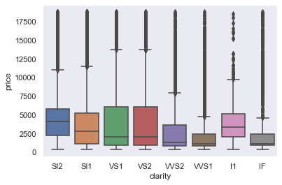

```python
sns.boxplot(x='clarity', y='price', data=df )
```

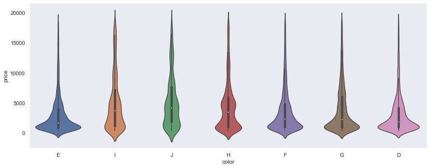

```python
sns.factorplot(x='color', y='price' , data=df , kind='violin', aspect=2.5)
```

**DATA - PRELIMINARY OBSERVATIONS**

# Method

Summarize the linear models (least-squares and LMS) and explain your implementation of **class** *LinearModel*. The explanation of your codes should not be the comments in a code cell. This section should include

- review of the linear models
- your implementation and description

**LINEAR MODELS**

Linear Regression show the relationship between the dependent and independent variables.

where w is a weight vector and x is an input vector. When it is a one dimensional vector, it represents a straight line, so it is called linear.

Assume that we have N data observations, xi and target outputs, ti, for i=1,⋯,N. The simplest model that we can think of is constant model, f(x)=c, where c is any scalar. In this case, we have the zero weights in the linear model.

The linearity in the parameter x make the optimization based on derivatives to solvable analytically. The model limits the complexity so its representation is also limited. However, it can prevent possible over fitting with the simple modeling, especially when you have sparsely sampled data.

Linear models describe a continuous response variable as a function of one or more predictor variables. They can help you understand and predict the behavior of complex systems or analyze experimental, financial, and biological data.

Linear regression is a statistical method used to create a linear model. The model describes the relationship between a dependent variable y (also called the response) as a function of one or more independent variables Xi (called the predictors). The general equation for a linear model is: **y=β0+∑ βiXi+ϵi**

where β represents linear parameter estimates to be computed and ϵ represents the error terms.

There are several types of linear regression:

Simple linear regression: models using only one predictor Multiple linear regression: models using multiple predictors Multivariate linear regression: models for multiple response variables Regression The target output t is s real number (y,t∈IR) as we discussed in last lecture. Thus, training f(x;w) generates y values close to the target outputs. We will discuss more about linear regression in next section.

Advantages of Linear Model

- Simple
- Stable
- Avoid Over fitting
- Scalable

**LEAST SQUARE**

Least Square is the simplest model of Regression. When we have more than one inputs we can use Least Square to estimate the optimal value of coefficients.

Residuals are the differences between the model's fitted value and observed value. Least Square minimizes the sum of Residuals. The most important application of LS is in Data Fitting. The exercise of minimizing these residuals would be the trial and error fitting of a line "through" the Cartesian coordinates representing these values. One way to proceed with the Least Squares Method is to solve via matrix multiplication. The least squares method can more formally be described as follows:

Matrices We then set up the matrix equation: **Y = XA = E**

Equation where matrix Y contains the Y values, matrix X contains a row of 1s and along with the X values, matrix A consists of the Y-intercept and slope, and matrix E is the errors. Note the row of 1s in matrix X are needed to allow multiplication with matrix A (2 rows and 2 columns, respectively).

This is the matrix equation ultimately used for the least squares method of solving a linear system.

**LEAST MEAN SQUARE**

The least mean square algorithm uses a technique called “method of steepest descent” and continuously estimates results by updating filter weights. Through the principle of algorithm convergence, the least mean square algorithm provides particular learning curves useful in machine learning theory and implementation.

Least Mean Squares Model

Here we have our other regression method, least mean squares. Least mean squares works by still attempting to minimize our error but now we do it in a online fashion. This means that we update our weights after observing each individual data sample, not the whole dataset at once. The following function is the function we want to minimize, this time though we do not want to expand the error function (we want to immediately take the derivative).

$$ w^{(k+1)} = w^{(k)} - \alpha \nabla E_k $$$$ E_k = \frac{\partial E}{\partial w^{(k)}} = \frac{\partial }{\partial w^{(k)}}\Big( f(x_k; w^{(k)}) - t_k \Big)^2 $$$$ E_K = 2\Big( {w^{(k)}}^\top x_k - t_k \Big) x_k. $$

*Since w.T @ x gives us our prediction, we subsitute it for f(x,w).*  
When we take the derivative with respect to *w* we get the following function. The functions reads as the following: our current weight *w* minus the learning rate (size of our steps we take towards the minimum) multiplied by the difference between our prediction and target and then lastly multiplied by the data currently being observed. LMS is great but comes at a cost of potentially never converging.

$$ w^{(k+1)} = w^{(k)} - \alpha \Big( {w^{(k)}}^\top x_k - t_k \Big) x_k. $$

### Super Classs Definition

```python
import numpy as np
from abc import ABC, abstractmethod

# Super class for machine learning models

class BaseModel(ABC):
    """ Super class for ITCS Machine Learning Class"""

    @abstractmethod
    def train(self, X, T):
        pass

    @abstractmethod
    def use(self, X):
        pass


class LinearModel(BaseModel):
    """
        Abstract class for a linear model

        Attributes
        ==========
        w       ndarray
                weight vector/matrix
    """

    def __init__(self):
        """
            weight vector w is initialized as None
        """
        self.w = None

    # check if the matrix is 2-dimensional. if not, raise an exception
    def _check_matrix(self, mat, name):
        if len(mat.shape) != 2:
            raise ValueError(''.join(["Wrong matrix ", name]))

    # add a basis
    def add_ones(self, X):
        """
            add a column basis to X input matrix
        """
        self._check_matrix(X, 'X')
        return np.hstack((np.ones((X.shape[0], 1)), X))

    ####################################################
    #### abstract funcitons ############################
    @abstractmethod
    def train(self, X, T):
        """
            train linear model

            parameters
            -----------
            X     2d array
                  input data
            T     2d array
                  target labels
        """
        pass

    @abstractmethod
    def use(self, X):
        """
            apply the learned model to input X

            parameters
            ----------
            X     2d array
                  input data

        """
        pass
```

#### Super class for machine learning models description

- Linear Model is the base class for implementation of classes Least square and Least mean square .
- Add_ones function is defined for adding a bias.
- Weight vector is initialized to none.
- train and use abstract methods are defined for future use.
- check_matrix function is defined to check the whether the matrix dimension is 2 or not is not 2 it raises an exception.

### Least Squares

```python
# Linear Regression Class for least squares
class LinearRegress(LinearModel):
    """
        LinearRegress class

        attributes
        ===========
        w    nd.array  (column vector/matrix)
             weights
    """
    def __init__(self):
        LinearModel.__init__(self)

    # train lease-squares model
    def train(self, X, T):

        N = X.shape[0]
        A1 = self.add_ones(X)
        self.w = np.linalg.inv(A1.T @ A1) @ A1.T @ T
        return self.w

    # apply the learned model to data X
    def use(self, X):
        N = X.shape[0]
        A1 = self.add_ones(X)
        y = A1 @ self.w

        return y
```

#### Least Square explanation

- Base model of Linear regression from super class is used in Least square.
- Train function trains the model using Linear Algebraic functions like inverse.
- use function returns the uses the learned model on Diamond dataset.

### Least Mean Squares

```python
import collections # for checking iterable instance

# LMS class
class LMS(LinearModel):
    """
        Lease Mean Squares. online learning algorithm

        attributes
        ==========
        w        nd.array
                 weight matrix
        alpha    float
                 learning rate
    """
    def __init__(self, alpha):
        LinearModel.__init__(self)
        self.alpha = alpha

    # batch training by using train_step function
    def train(self, X, T):
            for x, t in zip(X, T):
                self.train_step(x,t)


    # train LMS model one step
    # here the x is 1d vector
    def train_step(self, x, t):
        if len(x.T.shape) != 2:
            x = np.insert(x,0,1).reshape(-1,1)
        if self.w is None:
            self.w = np.zeros((x.shape[0],1))


        m=t.size
        h = self.w.T @ x
        h=h-t
        self.w =self.w - (self.alpha * h * x)


    def use(self, X):
        if len(X.T.shape) != 2:
            x = np.insert(x,0,1).reshape(-1,1)

        x = self.add_ones(X).T
        y = self.w.T @ x

        return y.T
```

#### Least Mean Square explanation

The LMS class contains the definition for the functions train, train-step and use which perform function as their names suggest.

In the train function the data is trained according to batch training by using train_step function. x is a one dimensional vector. The train_step function trains the data one step at a time. The use function applies the model to the Diamond dataset.

### Usage Examples

```python
# HERE follow are for my code tests.

import matplotlib.pyplot as plt
%matplotlib inline
```

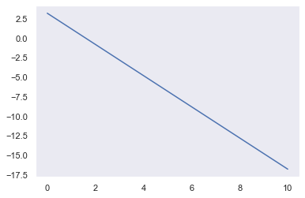

```python
X = np.linspace(0,10, 11).reshape((-1, 1))
T = -2 * X + 3.2

ls = LinearRegress()

ls.train(X, T)

plt.plot(ls.use(X))
```

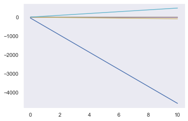

```python
lms = LMS(0.1)
for x, t in zip(X, T):
    lms.train_step(x, t)
    plt.plot(lms.use(X))
```

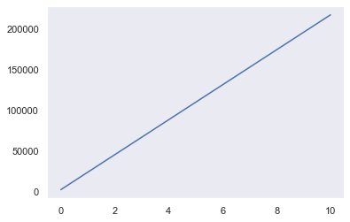

```python
lms.train(X, T)
plt.plot(lms.use(X))
```

# Experiments

Apply LS and LMS methods on the data and discuss the results. Please describe your experiment and related codes. You may have subsections of results and discussions here.

#### Splitting the Dataset into training and testing dataset in the ratio of 80:20 respectively.

```python
df.shape
```

```
(53940, 11)
```

```python
X = df[['carat','table','depth','x', 'y','z']].copy()
T = df[['volume']].copy()
```

Splitting of dataset is done using the **"iloc"** function into testing and training dataset of 80:20 ratio.

```python
data = df.sample(20000)
training_data = data.iloc[:16000,:]
testing_data = data.iloc[16000:20000,:]

X_on_Train = X.iloc[:16000,:]
X_on_Test = X.iloc[16000:20000,:]
T_on_Train = T.iloc[:16000,:]
T_on_Test = T.iloc[16000:20000,:]


X_Train = np.array(X_on_Train)
X_Test = np.array(X_on_Test)
T_Train = np.array(T_on_Train)
T_Test = np.array(T_on_Test)
```

**APPLYING LEAST SQUARE MODEL ON DIAMONDS DATASET AND VISUALIZING THE RESULTS**

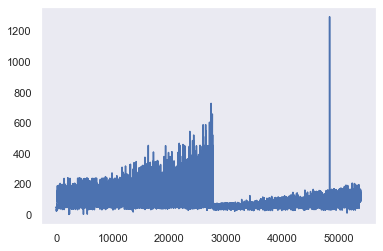

```python
LS = LinearRegress()

LS.train(X_Train, T_Train)
T_Predicted = LS.use(X_Test)
#print(T_Predicted)
#print(T_Test)
plt.plot(LS.use(X))
```

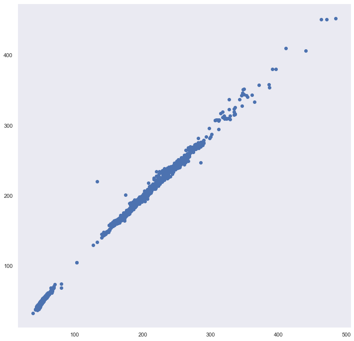

```python
plt.rcParams['figure.figsize'] = [12, 12]
plt.scatter(T_Test,LS.use(X_Test))
```

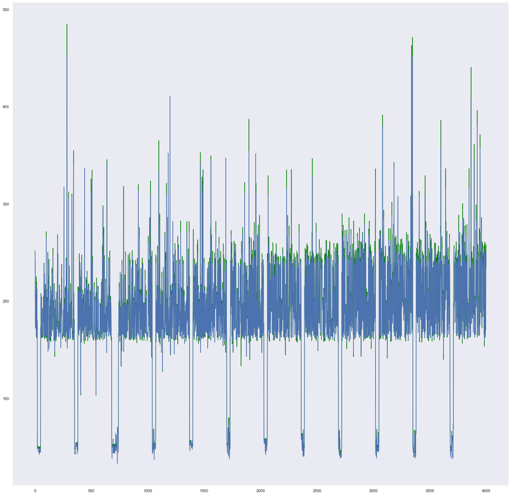

```python
plt.figure(figsize=(25,25))
plt.plot(T_Test,'g')
plt.plot(T_Predicted)
```

**APPLYING LEAST MEAN SQUARE TO DIAMOND DATASET AND VISUALIZING THE RESULTS**

```python
lms = LMS(0.0001)
lms.train(X_Train,T_Train)
T_Predict_lms = lms.use(X_Test)
#print(T_Predict_lms)
#print(T_Test)
```

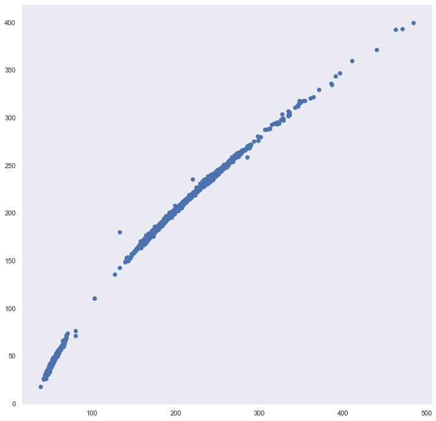

```python
for i in range(100):
    for x, t in zip(X_Train, T_Train):
        lms.train_step(x, t)
plt.scatter(T_Test, lms.use(X_Test))
```

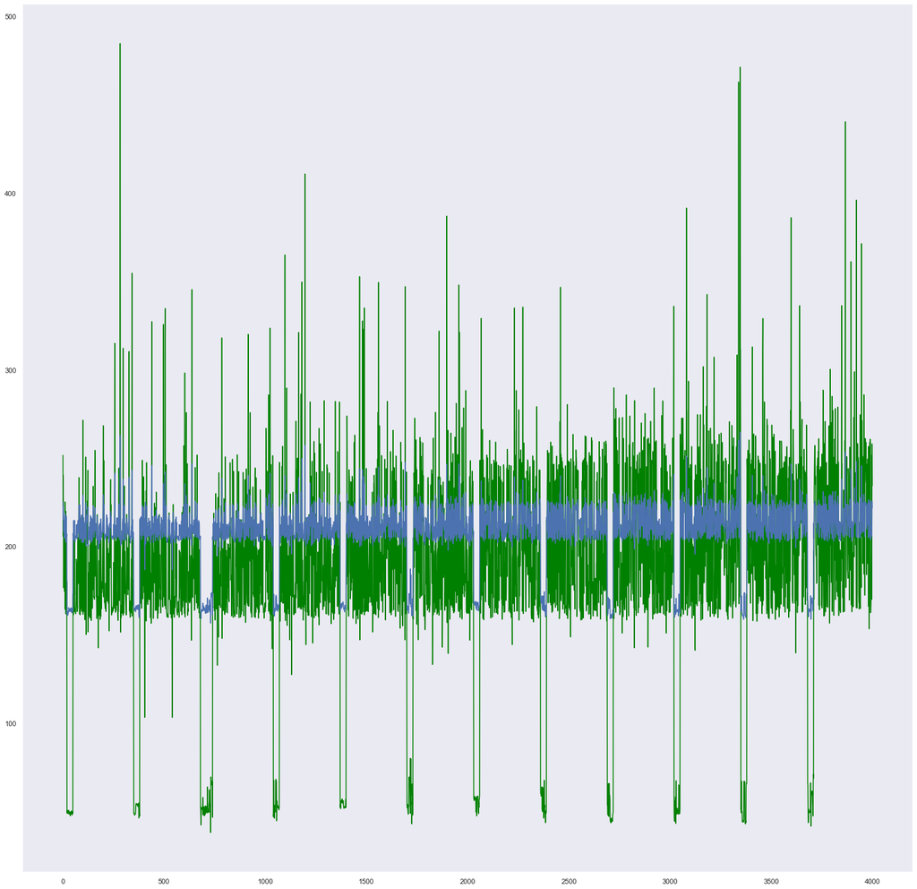

```python
plt.figure(figsize=(25,25))
plt.plot(T_Test,'g')
plt.plot(T_Predict_lms)
```

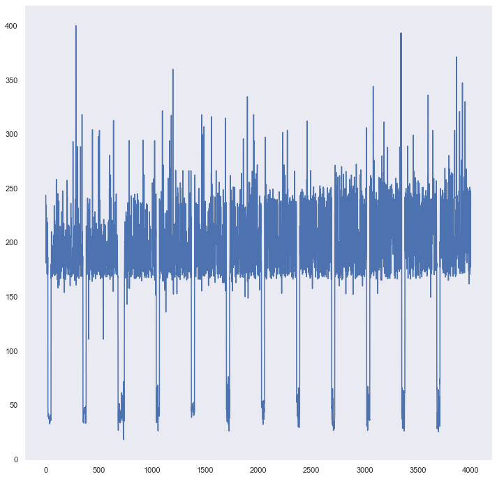

```python
lms.train(X_Train, T_Train)
plt.plot(lms.use(X_Test))
```

## Analysis / Comparisons of Algorithms

- Calculating the **Root mean square error** for Least Square and Least Mean Square.

```python
# RMSE for Least Square model
from sklearn.metrics import mean_squared_error
from math import sqrt
rmse = sqrt(mean_squared_error(T_Test, T_Predicted))
rmse
```

```
4.4206226216737585
```

```python
# RMSE for Least Mean Square model
rmse = sqrt(mean_squared_error(T_Test, T_Predict_lms))
rmse
```

```
46.1985765720211
```

From the above results of RMSE calculation the Least square model has way lesser rmse compared to Least Mean Square model, which tells us that the Least Sqaure model performs better than Least Mean square.

Computation of Least mean square model is heavier than Least Square.

For Least Mean Square we need to find the right value of alpha which can be done on trial and error basis. It quite difficult to find the optimal alpha for LMS.

Also from the plots above the my data better fits on Least Square as compared Least Mean Square.

Hence LS performs better than LMS.

# Conclusions

In this Assignment we have implemented the Linear Regression Models Least Square and Least Mean Square . We used the Diamond dataset for training and implementation of Linear Models.

In this assignment understanding the mathematical equations for LS and LMS and then dividing them into parts and coding them was a challenging part.

After comparing the LS and LMS it is evident that LS performs better as it has less complexity, and does not require much trails also.

# References

1. Goodfellow, I., Bengio, Y. and Courville, A. (2018). Deep learning.
2. Professor's Notebook: “Notebook on Nbviewer.” Jupyter Notebook Viewer, https://nbviewer.jupyter.org/url/webpages.uncc.edu/mlee173/teach/itcs6156/notebooks/notes/Note-Linear Model.ipynb.
3. GeeksforGeeks. (2019). Data visualization with different Charts in Python - GeeksforGeeks. [online] Available at: https://www.geeksforgeeks.org/data-visualization-different-charts-python/ [Accessed 10 Sep. 2019].
4. Matplotlib.org. (2019). Overview — Matplotlib 3.1.1 documentation. [online] Available at: https://matplotlib.org/3.1.1/contents.html [Accessed 10 Sep. 2019]
5. Shivamagrawal. “Diamonds.” Kaggle, 25 May 2017, https://www.kaggle.com/shivam2503/diamonds.
6. “What Is the Least Mean Square Algorithm (LMS Algorithm)? - Definition from Techopedia.” Techopedia.Com, 2019, www.techopedia.com/definition/33276/least-mean-square-algorithm-lms-algorithm. Accessed 23 Sept. 2019.

# Extra Credit

If you want to work more for an extra credit, place your work here for additional analysis: weight and residual analysis. Try to answer to the following questions:

- what is the most and least significant features for your data.
- what are the consequences if you remove those features from the model? (Show your work!)
- produce residual plots and observe the patterns for the goodness of fit

**Note: the extra credit is an additional work that needs complete programming, experiments, analysis, and writing to get one.**

- what is the most and least significant features for your data.

```python
X = df[['carat','x', 'y','z']].copy()
T = df[['volume']].copy()
```

```python
data = df.sample(20000)
training_data = data.iloc[:16000,:]
testing_data = data.iloc[16000:20000,:]

X1_on_Train = X.iloc[:16000,:]
X1_on_Test = X.iloc[16000:20000,:]
T1_on_Train = T.iloc[:16000,:]
T1_on_Test = T.iloc[16000:20000,:]


X1_Train = np.array(X1_on_Train)
X1_Test = np.array(X1_on_Test)
T1_Train = np.array(T1_on_Train)
T1_Test = np.array(T1_on_Test)
```

[output not shown]

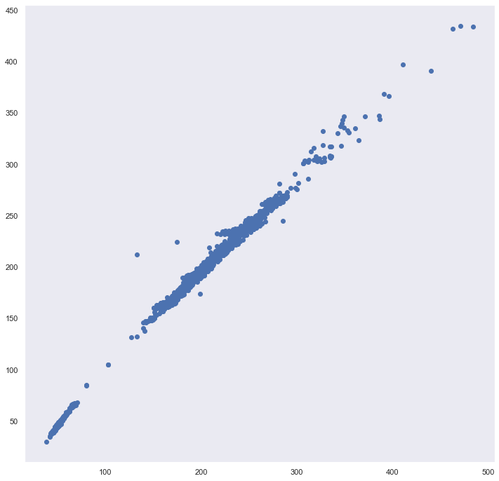

```python
plt.rcParams['figure.figsize'] = [12, 12]
ls = LinearRegress()
ls.train(X1_Train, T1_Train)
y = ls.use(X1_Test)
plt.scatter(T1_Test,ls.use(X1_Test))
print('Weights after Least Square: {0}'.format(ls.w))
```

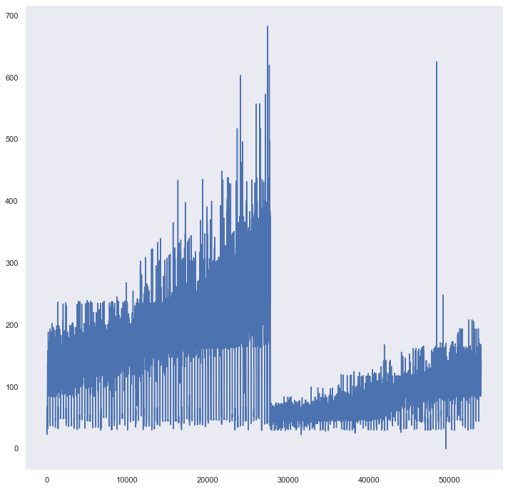

```python
LS = LinearRegress()

LS.train(X1_Train, T1_Train)
T1_Predicted = LS.use(X1_Test)
#print(T_Predicted)
#print(T_Test)
plt.plot(LS.use(X))
```

```python
lms = LMS(0.0001)
lms.train(X1_Train,T1_Train)
T1_Predict_lms = lms.use(X1_Test)
#print(T_Predict_lms)
#print(T_Test)
```

[output not shown]

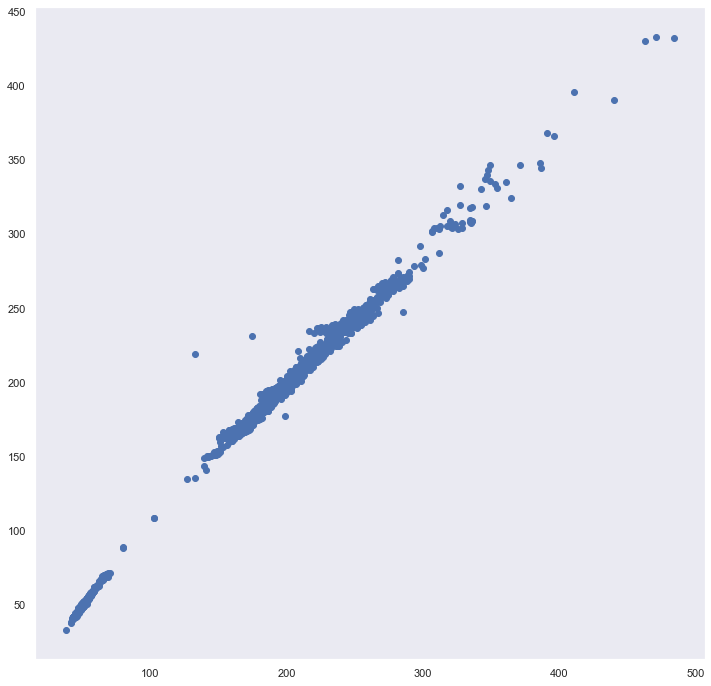

```python
for i in range(100):
    for x, t in zip(X1_Train, T1_Train):
        lms.train_step(x, t)
plt.scatter(T1_Test, lms.use(X1_Test))
print('Weights after Least Mean Square: {0}'.format(lms.w))
```

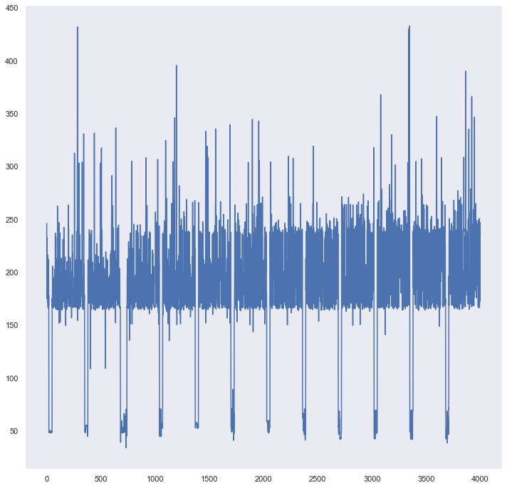

```python
lms.train(X1_Train, T1_Train)
plt.plot(lms.use(X1_Test))
```

```python
# RMSE for Least Square model
from sklearn.metrics import mean_squared_error
from math import sqrt
rmse = sqrt(mean_squared_error(T1_Test, T1_Predicted))
print(rmse)
# RMSE for Least Mean Square model

rmse = sqrt(mean_squared_error(T1_Test, T1_Predict_lms))
print(rmse)
```

```
6.251366369437745
32.1764768930934
```

```python
X = df[['carat','table','depth']].copy()
T = df[['volume']].copy()
```

```python
data = df.sample(20000)
training_data = data.iloc[:16000,:]
testing_data = data.iloc[16000:20000,:]

X2_on_Train = X.iloc[:16000,:]
X2_on_Test = X.iloc[16000:20000,:]
T2_on_Train = T.iloc[:16000,:]
T2_on_Test = T.iloc[16000:20000,:]


X2_Train = np.array(X2_on_Train)
X2_Test = np.array(X2_on_Test)
T2_Train = np.array(T2_on_Train)
T2_Test = np.array(T2_on_Test)
```

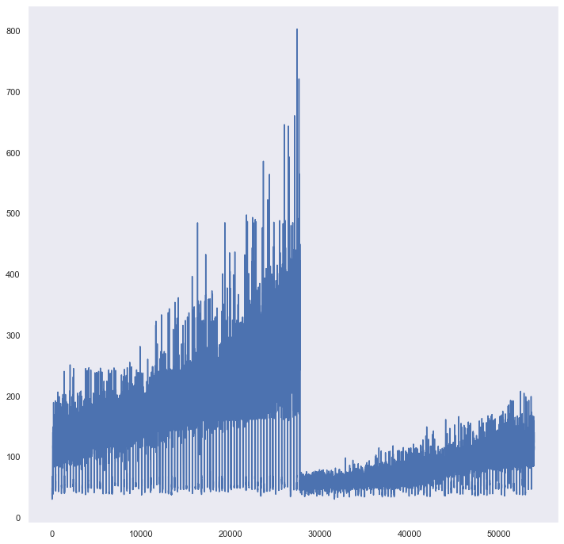

```python
LS = LinearRegress()

LS.train(X2_Train, T2_Train)
T_Predicted = LS.use(X2_Test)
#print(T_Predicted)
#print(T_Test)
plt.plot(LS.use(X))
```

[output not shown]

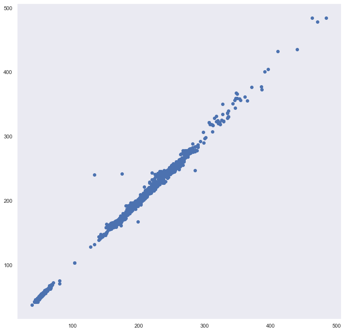

```python
plt.rcParams['figure.figsize'] = [12, 12]
plt.scatter(T2_Test,LS.use(X2_Test))
print('Weights after Least Square: {0}'.format(LS.w))
```

```python
lms = LMS(0.0001)
lms.train(X2_Train,T2_Train)
T_Predict_lms = lms.use(X2_Test)
#print(T_Predict_lms)
#print(T_Test)
```

[output not shown]

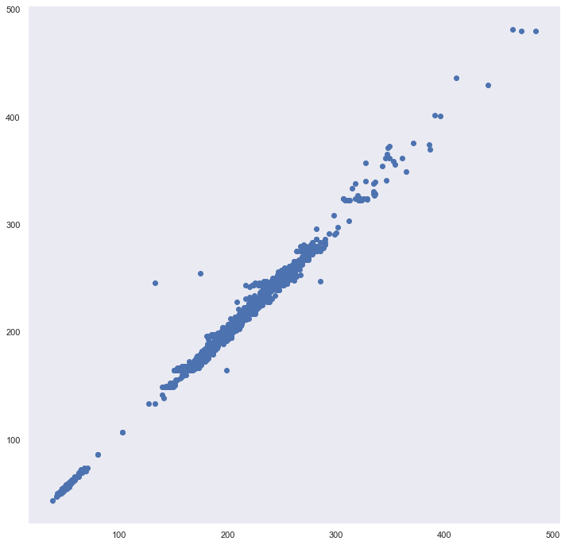

```python
for i in range(100):
    for x, t in zip(X2_Train, T2_Train):
        lms.train_step(x, t)
plt.scatter(T2_Test, lms.use(X2_Test))
print('Weights after Least Square: {0}'.format(lms.w))
```

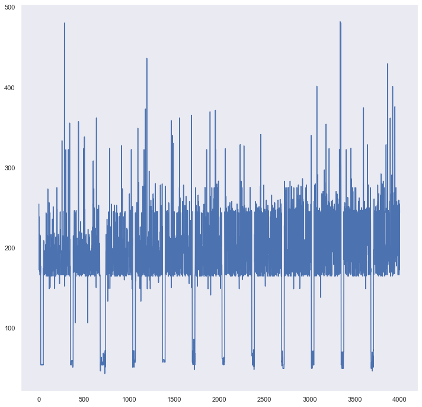

```python
lms.train(X2_Train, T2_Train)
plt.plot(lms.use(X2_Test))
```

```python
# RMSE for Least Square model
from sklearn.metrics import mean_squared_error
from math import sqrt
rmse = sqrt(mean_squared_error(T2_Test, T_Predicted))
print(rmse)
# RMSE for Least Mean Square model

rmse = sqrt(mean_squared_error(T2_Test, T_Predict_lms))
print(rmse)
```

```
3.717516510704795
62.64259368115151
```

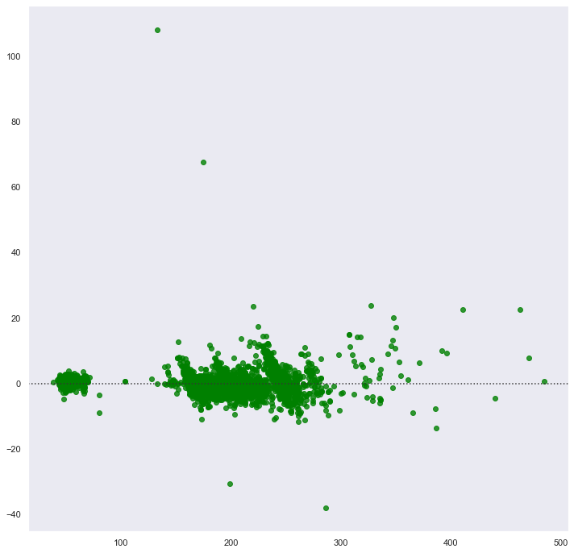

```python
#Residual Plot for Least Squares with Table,Depth Features
sns.residplot(T_Test, T_Predicted, color="g")
```

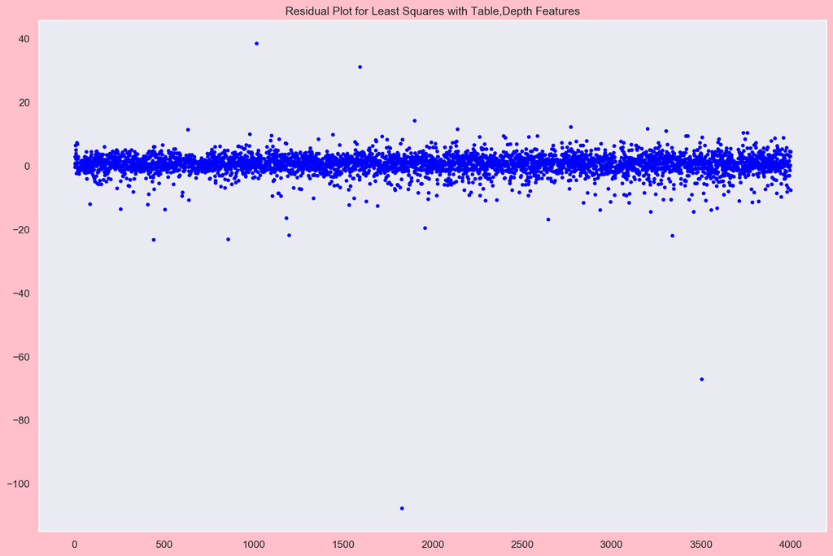

```python
error = T_Test - T_Predicted
fig=plt.figure(figsize=(15, 10), dpi= 150, facecolor='pink')
n = np.arange(len(T2_Test))
plt.scatter(n,error,marker='.',color='b')
plt.title("Residual Plot for Least Squares with Table,Depth Features")
```

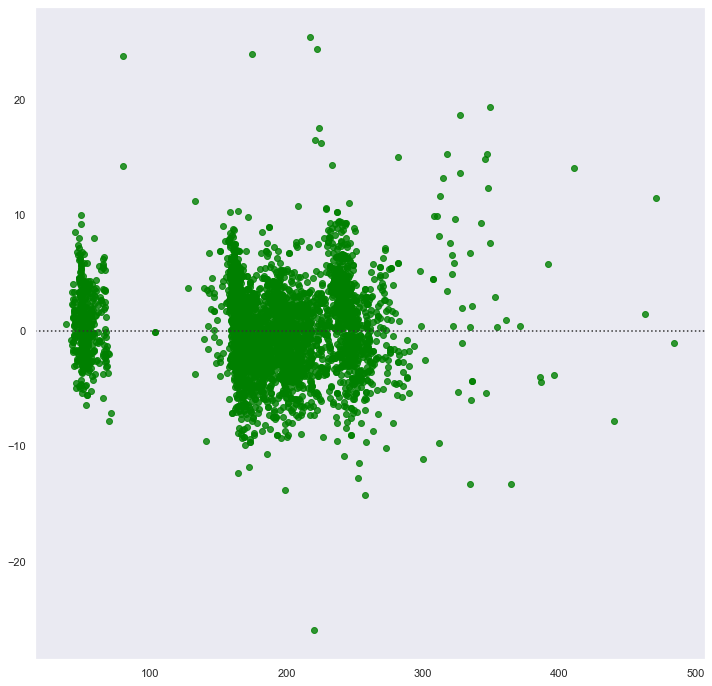

```python
#Residual plot for Least Mean Squares with Depth, Table Features"
sns.residplot(T_Test, T_Predict_lms, color="g")
```

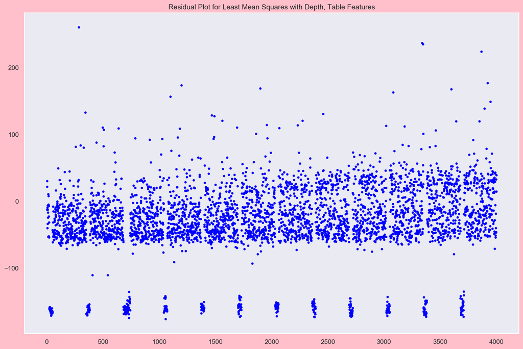

```python
error = T2_Test - T_Predict_lms
fig=plt.figure(figsize=(15, 10), dpi= 150, facecolor='pink')
n = np.arange(len(T_Test))
plt.scatter(n,error,marker='.',color='b')
plt.title("Residual Plot for Least Mean Squares with Depth, Table Features")
```